# Acidentes nas rodovias federais de Pernambuco em 2018

Ítalo Lemos

06/07/2019

# Introdução

Os acidentes de trânsito são reconhecidos pela Organização Mundial de Saúde (OMS) como um grave problema de saúde pública e uma das principais causas de mortes e lesões em todo o mundo. Além do elevado custo para os serviços de saúde e para as economias dos países, podendo atingir de 1% a 3% do Produto Interno Bruto (PIB) (ONU, 2011), os acidentes de trânsito desencadeiam diversos traumas para a sociedade e as relações sociais, além de acarretar a perda precoce de vidas. É necessário compreender que o trânsito é primordial para o desenvolvimento nacional. Facilita a circulação de pessoas e bens, melhora o acesso à educação, aos serviços de saúde, ao emprego e ao desenvolvimento. A Segurança Viária envolve a responsabilidade quanto à mobilidade das pessoas e veículos na via, bem como a complexa dinâmica de compartilhamento de espaço, até o estabelecimento de normas de circulação com o objetivo de proteger os usuários e evitar reflexos negativos em todo o aparato estatal.

O Plano Nacional de Redução de Mortes e Lesões no Trânsito (PNATRANS), acrescentando o artigo 326-A ao Código de Trânsito Brasileiro (CTB), e propôs um novo desafio para a gestão de trânsito no Brasil e para os órgãos integrantes do Sistema Nacional de Trânsito (SNT). O Plano, elaborado em conjunto pelos órgãos de saúde, de trânsito, de transporte e de justiça, traz as diretrizes para que o país reduza em, no mínimo, metade o índice nacional de mortos por grupo de veículos e o índice nacional de mortos por grupo de habitantes. Para tanto, estabelece um prazo de dez anos. As metas de redução de mortes e lesões no trânsito, fixadas pelo Conselho Nacional de Trânsito (CONTRAN), para cada um dos Estados da Federação e para o Distrito Federal, a partir das propostas dos Conselhos Estaduais de Trânsito (CETRAN), do Conselho de Trânsito do Distrito Federal (CONTRANDIFE) e do Departamento de Polícia Rodoviária Federal (DPRF), no âmbito das respectivas circunscrições, garante que todos sejam chamados a contribuir.

A Polícia Rodoviária Federal publica sistematicamente os principais dados constando do Boletim de Ocorrência de cada acidente registrado como ocorrido nas rodovias federais: número das vitimas e gravidade, tipo de acidente, causa principal, configuração do local, condições climáticas, fase do dia, etc.

O processamento destes dados permite estabelecer estatísticas de acidentes e de vítimas em cada estado e cada rodovia e em qualquer trecho de rodovia que se queira estudar com mais detalhe. Assim, permite identificar os locais de maior concentração de acidentes e analizar todos os acidentes ocorridos em cada local.

Este Trabalho visa analisar apenas ocorrências no estado de Pernambuco

# Pacotes Requeridos

Para este projeto foram utilizado os seguintes pacotes padrões para organização e manipulação de dados e também na visualização.

```r
library(tidyr)        # Organização de dados
library(dplyr)        # Manipulação de dados
library(ggplot2)      # Geração de gráficos
library(DT)           # Criar tabelas funcionais em HTML
library(zoo)          # Formatação de Datas
library(knitr)        # Relatórios Dinâmicos
library(kableExtra)   # Criar tabelas funcionais em HTML
library(janitor)      # Examinar e limpeza de dados
library(tm)           # Manipulação de Texto
library(wordcloud)    # Manipulação de Texto
library(RColorBrewer) # Manipulação de Texto
```

# Preparação dos dados

Para este projeto, utilizei a base dados de acidentes em rodovias federais brasileiras no ano de 2018. Essa base de dados é mantida pela Polícia Rodoviária Federal (PRF) e é disponibilizada em seu site através de seu portal de dados abertos. Nesse portal também é possível encontrar dados referentes as infrações de trânsito.

```r
df <- read.csv("datatran2018.csv", sep = ";", dec = ",", encoding = "latin1", na.strings = "")


datatable(head(df))
```

Após realizar uma avaliação de quais variáveis seriam úteis para uma melhor análise exploratória, foram selecionadas para este trabalho:

- data_inverva
  - Data da ocorrência
- dia_semana
  - Dia da semana da ocorrência
- horario
  - Horário da ocorrência
- uf
  - Unidade da Federação ex.: MG, PE, DF
- km
  - Identificação do quilômetro onde ocorreu o acidente
- municipio
  - Nome do município de ocorrência do acidente
- causa_acidente
  - Identificação da causa principal do acidente
- tipo_acidente
  - Identificação do tipo de acidente
- classificação_acidente
  - Classificação quanto à gravidade do acidente: Sem Vítimas, Com Vítimas Feridas, Com Vítimas Fatais e Ignorado
- condição_meteorologica
  - Condição meteorológica no momento do acidente: Céu claro, chuva, vento, etc
- latitude
  - Latitude do local do acidente em formato geodésico decimal.
- longitude
  - Longitude do local do acidente em formato geodésico decimal.
- pessoas
  - Total de pessoas envolvidas na ocorrência
- mortos
  - Total de pessoas mortas envolvidas na ocorrência
- feridos
  - Total de pessoas feridas envolvidas na ocorrência

A primeira etapa é filtar apenas as ocorrências registradas no estado de Pernambuco, para uma análise mais completa. Além de filtrar pelo estado cidade, selecio apenas as variáveis que seram utilizadas.

```r
# dados de PE
dfPernambuco <- df %>%
  select(data_inversa, dia_semana, horario, uf, br, km, municipio, causa_acidente, tipo_acidente, classificacao_acidente,
         fase_dia, condicao_metereologica, feridos, mortos,  veiculos, latitude, longitude) %>%
  filter(uf == "PE")
```

Em seguida, analisamos a nova base gerada para identificar características relevantes sobre as varíaveis.

```r
str(dfPernambuco)
```

```
## 'data.frame':    2714 obs. of  17 variables:
##  $ data_inversa          : Factor w/ 365 levels "2018-01-01","2018-01-02",..: 1 1 1 1 1 1 1 1 1 2 ...
##  $ dia_semana            : Factor w/ 7 levels "domingo","quarta-feira",..: 5 5 5 5 5 5 5 5 5 7 ...
##  $ horario               : Factor w/ 1292 levels "00:00:00","00:01:00",..: 147 152 173 608 787 884 1014 1078 1162 306 ...
##  $ uf                    : Factor w/ 27 levels "AC","AL","AM",..: 16 16 16 16 16 16 16 16 16 16 ...
##  $ br                    : Factor w/ 114 levels "10","101","104",..: 20 2 2 20 20 2 38 2 20 20 ...
##  $ km                    : Factor w/ 8046 levels "0","0,1","0,2",..: 5223 6256 4953 7948 5625 3491 6348 1008 181 1824 ...
##  $ municipio             : Factor w/ 1780 levels "ABADIA DE GOIAS",..: 1250 1319 1179 1389 1250 704 1118 624 189 114 ...
##  $ causa_acidente        : Factor w/ 24 levels "Agressão Externa",..: 5 5 11 17 11 11 11 22 11 11 ...
##  $ tipo_acidente         : Factor w/ 16 levels "Atropelamento de Animal",..: 5 15 3 3 8 7 6 5 15 8 ...
##  $ classificacao_acidente: Factor w/ 3 levels "Com Vítimas Fatais",..: 2 2 3 3 3 3 1 2 1 2 ...
##  $ fase_dia              : Factor w/ 4 levels "Amanhecer","Anoitecer",..: 3 3 3 4 4 2 3 3 3 4 ...
##  $ condicao_metereologica: Factor w/ 9 levels "Céu Claro","Chuva",..: 1 1 9 1 1 1 1 1 1 8 ...
##  $ feridos               : int  1 1 0 0 0 0 0 1 0 1 ...
##  $ mortos                : int  0 0 0 0 0 0 1 0 1 0 ...
##  $ veiculos              : int  1 1 1 1 2 2 2 1 1 2 ...
##  $ latitude              : Factor w/ 51918 levels "-0.456592","-0.57932188",..: 49088 48673 48351 49453 49112 48162 48153 48056 49329 49642 ...
##  $ longitude             : Factor w/ 52042 levels "-34.82769012",..: 2275 827 486 2495 2289 507 9160 923 2643 3967 ...
```

Feito isso, identifico que algumas varíaveis necessitam passar por uma conversão de tipo de dados. A variável Data, e km são fatores. Converto elas para o tipo date e numérico, respectivamente, através da seguinte operação. Pois elas seram utilizadas em algumas análises. E algumas funções necessitam que esses dados estejam em seu formato real.

```r
dfPernambuco$data_inversa <- as.Date(dfPernambuco$data_inversa, format ="%Y-%m-%d")
dfPernambuco$km <- sub(",", ".", dfPernambuco$km)
dfPernambuco$km <- as.numeric(dfPernambuco$km)
```

Assim obtemos os dados necessários para nossa análise. A base contendo os registros de Pernambuco contém 2714 observações.

# Análise Exploratória dos dados

Essa seção tem o objetivo de mostrar quais insights podem ser descobertos a partir de uma exploração dos dados sobre acidentes em rodovias federais no estado Pernambuco em 2018.

A primeira análise visa descobrir em quais rodovias incide a maior e menor quantidade de ocorrências de acidentes, indenpente to tipo de causa ou quantidade de mortes. Essa informação é obida através da seguinte

```r
#Acidentes por rodovias
acidentes_por_estrada <- dfPernambuco %>%
  na.omit() %>%
  count(br, sort = T)
```

Após a manipulação de dados podemos gerar o respectivo gráfico

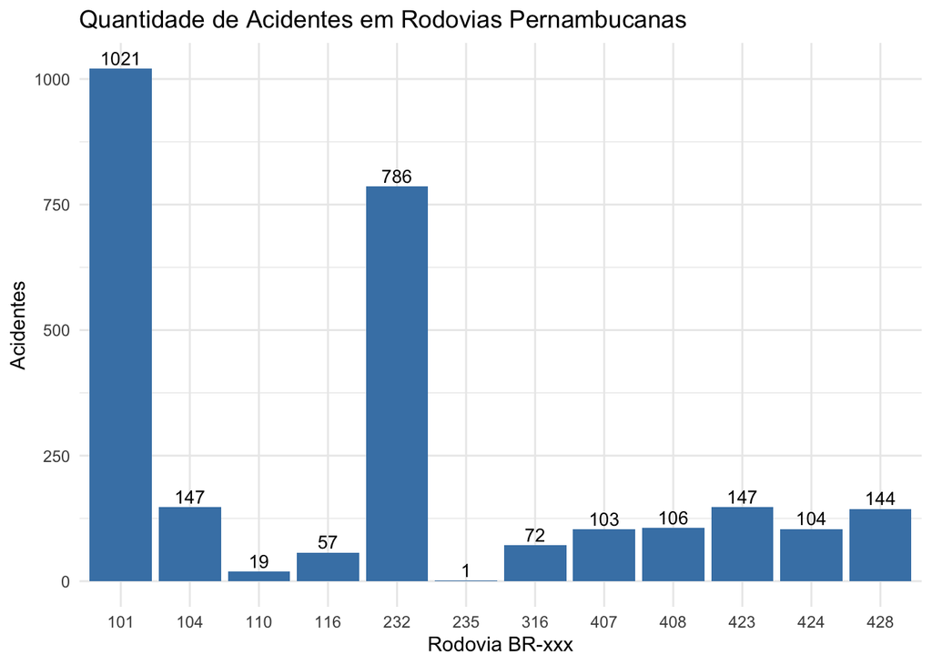

```r
ggplot(data = acidentes_por_estrada, aes(x = as.character(br), y = n)) +
  labs(title="Quantidade de Acidentes em Rodovias Pernambucanas", y="Acidentes", x="Rodovia BR-xxx") +
  geom_bar(stat="identity", fill="steelblue") +
  geom_text(aes(label=n), vjust=-0.3, size=3.5) +
  theme_minimal()
```

Através do gráfico gerado, temos informações relevantes como que a BR-101 e BR-232 concentram a maioria das ocorrências no estado. Enquanto a BR-235, localizada na cidade de Petrolina, possuiu a menor fatia de acidentes em 2018. A BR-101 corta 12 estados brasileiros na direção de norte a sul através do litoral. Devido a sua importância rodoviária apresenta em seu trecho dentro do estado o maior número de acidentes. A BR-232, é a principal ligação da capital rumo ao interior do estado. Por esse motivo figura como uma das que mais ocorre acidentes. Esses dados sugerem em quais rodovias deve ter uma maior atenção dos motoristas quantos das autoridades policiais.

A próxima análise refere em descobrir em quais meses do ano a uma maior incidência de acidentes. Nesta análise foi necessário a criação da variável month, ela é necessária para agrupar a relação por meses. Obtendo a relação meses x quantidade de acidantes. Ela é obtida através do seguinte script

```r
mes_acidente <- dfPernambuco %>%
  select(data_inversa) %>%
  mutate(month = format(data_inversa, "%Y-%m")) %>%
  group_by(month) %>%
  summarise(
    acidentes = n()
  )
```

Em seguida, convertemos a variável month para o formato do tipo data. Cada mês será convetido para o primeiro dia do mês no formato Year-month-day.

```r
mes_acidente$month <- as.Date(as.yearmon(mes_acidente$month))
```

Assim podemos gerar o seguinte gráfico baseado nos meses.

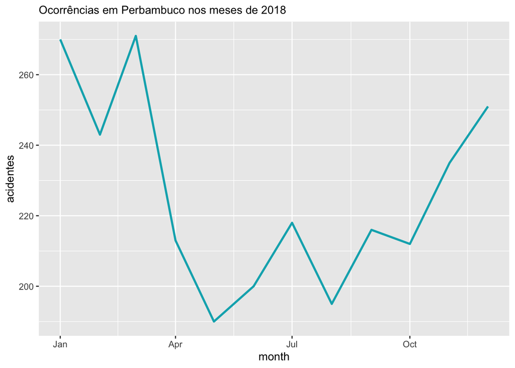

```r
ggplot(data = mes_acidente, aes(x = month, y = acidentes, group = 1)) +
  geom_line(color = "#00AFBB", size = 1) + scale_x_date(date_labels = "%b") +
  labs(subtitle = "Ocorrências em Perbambuco nos meses de 2018")
```

A partir do gráfico concluimos que os primeiros meses do ano apresentam um maior quantititativo de acidentes. Podemos relacionar a grande quantidade de ocorrências nestes meses devido a serem típicos meses de férias e com o início da estação verão.

Em nossa próxima análise, objetivamos obter quais são os tipos mais frequentes de acidentes. Analisaremos quais a quantidade de feridos e a quantidade de mortes ocassionada por cada tipo. Nessa análise obteremos a contagem de acidente e o somatório de feridos e mortos por categoria.

```r
# Acidentes por tipo
acidentes_pelo_tipo <- dfPernambuco %>%
  group_by(tipo_acidente) %>%
  summarise(
    Acidentes = n(),
    Feridos = sum(feridos),
    Mortos = sum(mortos)
  ) %>%
  adorn_totals("row")
```

Essa tabela pode ser melhor visualizada através do uso de bibliotecas externas, por essa maneira

```r
kable(acidentes_pelo_tipo) %>%
  kable_styling("striped", full_width = F) %>%
  row_spec(c(2, 6, 15), bold = T, color = "white", background = "#D7261E") %>%
  row_spec(17, bold = T, color = "black", background = "#D3D3D3")
```

| tipo_acidente | Acidentes | Feridos | Mortos |
| --- | --- | --- | --- |
| Atropelamento de Animal | 85 | 59 | 8 |
| Atropelamento de Pedestre | 176 | 171 | 48 |
| Capotamento | 151 | 192 | 14 |
| Colisão com objeto em movimento | 13 | 15 | 0 |
| Colisão com objeto estático | 152 | 122 | 11 |
| Colisão frontal | 245 | 352 | 66 |
| Colisão lateral | 385 | 357 | 27 |
| Colisão transversal | 335 | 398 | 30 |
| Colisão traseira | 550 | 501 | 35 |
| Danos eventuais | 19 | 6 | 0 |
| Derramamento de carga | 2 | 0 | 0 |
| Engavetamento | 41 | 32 | 0 |
| Incêndio | 30 | 0 | 0 |
| Queda de ocupante de veículo | 65 | 66 | 10 |
| Saída de leito carroçável | 351 | 385 | 40 |
| Tombamento | 114 | 96 | 6 |
| Total | 2714 | 2752 | 295 |

Nossa próxima análise será de mineração de texto. Procuro saber quais são as palavras mais empregadas pelos agentes para especificar a causa de um acidente. Tento nessa análise descobrir a frequência no uso de palavras como velocidade, álcool etc. Nessa análise, uso o conceito de geração de nuvem de palavras, para localizar as palavras mais usadas na variável causa de acidentes. Nessa etapa é importe carregar os pacotes necessários para a mineração do texto. O primeiro passo é colapsar todos os comentários em um vetor e em seguida converter esse vetor em um corpus, que é uma coleção de documentos, que será processado. Em seguida é realizada uma limpeza nos dados, para remover pontuação, espaços e outros ruídos. Por último, cria-se uma matriz de termo-documento, que se trata de uma tabela que contém a frequência das palavras.

```r
motivos <- paste(dfPernambuco$causa_acidente, copllapse = " ")

# Criar corpus
corpus <- Corpus(VectorSource(motivos))

#limpeza de dados
#Coloca tudo em minusculo
corpus <-tm_map(corpus, tolower)
#Remove pontuação
corpus <-tm_map(corpus, removePunctuation)
#Remove números
corpus <-tm_map(corpus, removeNumbers)
#Remove espaços extras em branco
corpus <-tm_map(corpus, stripWhitespace)
#Remove palavras ruído
corpus <-tm_map(corpus, removeWords, stopwords('portuguese'))

#Converte para o formato de uma matriz.
tdm<-as.matrix(TermDocumentMatrix(corpus))

#Fornece as frequências ordenadas de cada palavra.
fre<-sort(rowSums(tdm),decreasing=TRUE)
```

Ao final, podemos plotar um gráfico do tipo de barras contendo as palavras mais frequentes

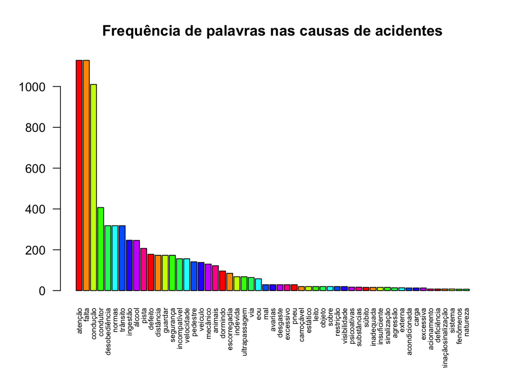

```r
#Escolhendo um subconjunto dos dados.
aux<-subset(fre, fre>2)

#Gerar o gráfico.
barplot(aux, las=2, col= rainbow(10), cex.names= 0.6, main = "Frequência de palavras nas causas de acidentes")
```

A frequência de palavras mais usadas estão entre elas “atenção”, “falta”, “condução”, “condutor”, “desobidiência”, “normas”. Podemos levantar a hipótese de que os acidentes ou a grande maioria deles são sempre falhas humanas. Já que as palavras mais frequentes referem-se a atenção dos motoristas. Os termos que indicam problemas estruturais na rodovias, como sinalização ou infraestura aparecem em menor frequência

```r
# fase do dia
acidentes_fase_dia <- dfPernambuco %>%
  na.omit() %>%
  select(br, fase_dia) %>%
  gather(br, fase_dia) %>%
  group_by(br, fase_dia) %>%
  summarise(
    acidentes = n()
  )
```

A partir dessas informações, é possóvel gerar um gráfico de barras para comparar a parte com o todo. As barras representam o total de acidentes, nessa caso dividimos por rodovia, e dentro da barra representa um grupo de categorias. Assim o gráfico fica da seguinte forma

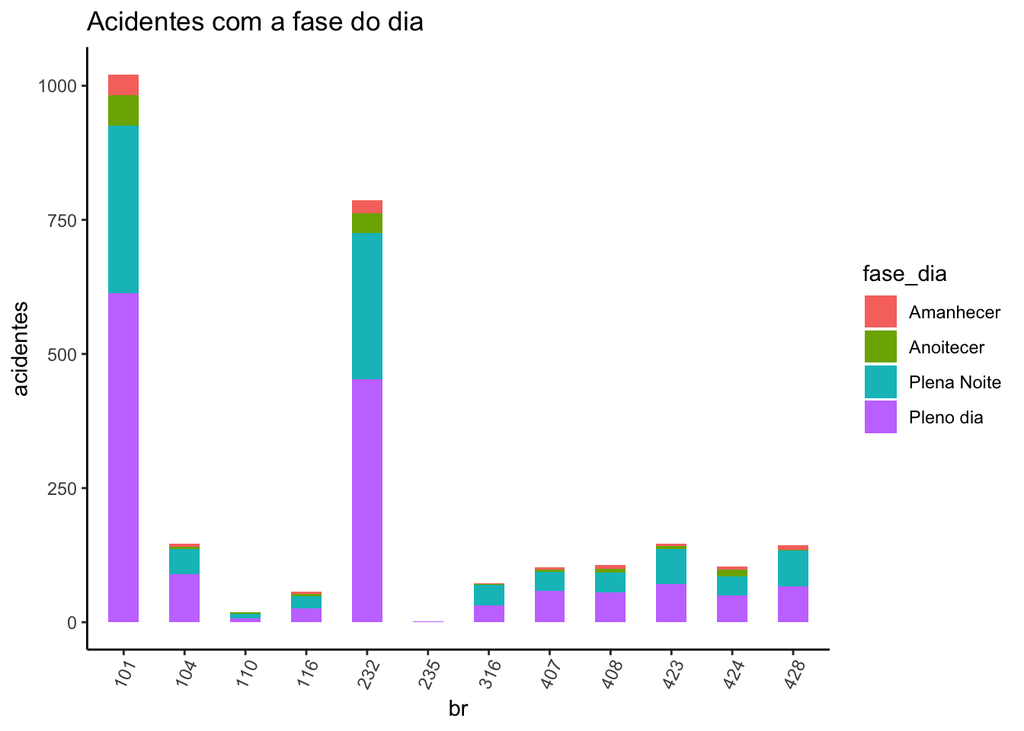

```r
theme_set(theme_classic())

ggplot(acidentes_fase_dia, aes(x=br, y=acidentes)) +
  geom_bar(aes(fill=fase_dia), width = 0.5, stat="identity") +
  theme(axis.text.x = element_text(angle=65, vjust=0.6)) +
  labs(title="Acidentes com a fase do dia ")
```

A ultima análise, refere-se a descobrir o comportamento de acidentes e mortes no período de são joão na BR-232. Já que se trata de um evento que eleva o número de deslocamentos ao interior do estado, principalmente para a cidade de Caruaru. Levando em consideração que caruaru está situada no km 135 da rodovia, analisaremos a quantidade de acidentes e mortos no período do mês de junho.

```r
# acidentes no sao joão em br 232
acidentes_recife_caruaru_junho <- dfPernambuco %>%
  filter(br == 232,
         between(data_inversa, as.Date("2018-06-01"), as.Date("2018-06-30")),
         between(km, 1, 140)) %>%
  group_by(dia_semana) %>%
  summarise(
    acidentes = n(),
    mortes = sum(mortos)
  )
```

O que possibilita gerar esse gráfico, dividindo as ocorrências por dias da semana durante todo o mês

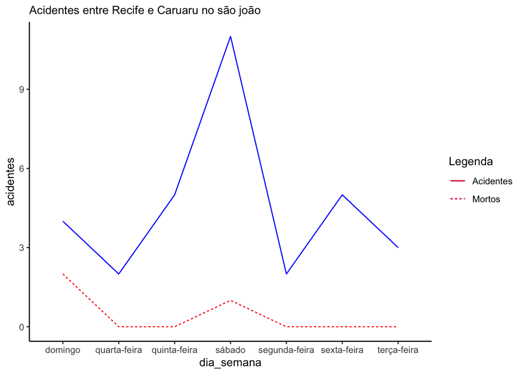

```r
ggplot(acidentes_recife_caruaru_junho, aes(dia_semana, group = 1)) +
  geom_line(aes(y=acidentes, lty = 'Acidentes'), stat = "identity", col = "blue") +
  geom_line(aes(y=mortes, lty = "Mortos"), stat = "identity", col = "red") +
  labs(subtitle = "Acidentes entre Recife e Caruaru no são joão") +
  scale_linetype('Legenda')
```

# Conclusões

Foi observado que Pernambuco possui características peculiares em suas rodovias, que podem ser diferentes das de outros estados. O fato é que mesmo o PNATRAS iniciando em 2018, o estado contou com muitos acidentes em suas estradas. Através desta análise foi possível observar padrões de determinadas rodovias assim como entender o comportamento da grande maioria dos motoristas que trafegam pela região. Entender como é o comportamento do motorista pode contribuir para bastante para criar metas na a redução de acidentes e consequentemente o número de vítimas.

Iniciativas de melhoria do trânsito como ampliação de meios de fiscalização eletrônica e foco na educação no trânsito são necessidades requeridas após este estudo. Uma questão obeservada no trabalho é que grande parte dos acidentes ocorrem por falha humana. É preciso formentar projetos que estimulem a vivência no trânsito como medida de prevenção.

Visto que a Polícia Rodoviária Federal disponibiliza em seu portal de dados abertos, dados referentes a infrações de trânsitos cometidas. Há a possibilidade buscar uma relação de infrações com ocorrência de acientes, tentando obter alguma co-relação entre os dois temas.